# Statistical Analysis with R

## Adding a regression line

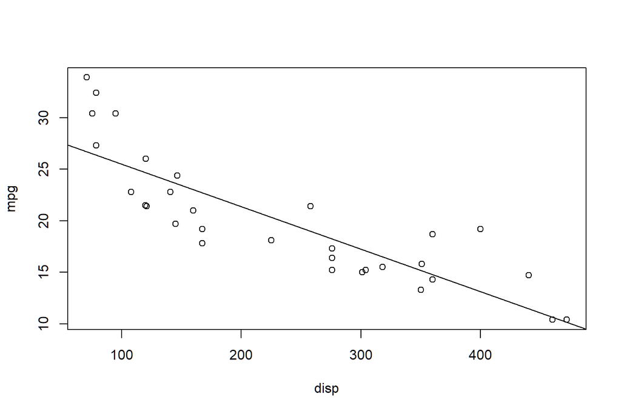

```r
with(mtcars, plot(disp, mpg))
abline(coef(lm(mpg ~ disp, mtcars)))   # coef(lm(...)) returns intercept and slope
```

## `ggplot2`

## The `ggplot2` package

**Grammar of Graphics**

- framework to build plots layer-by-layer
- each layer describes a component of the plot

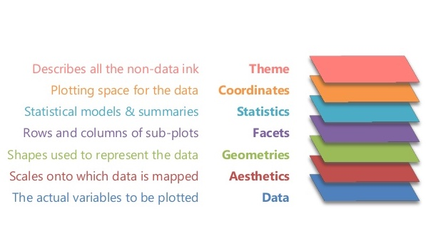

## Content of building blocks

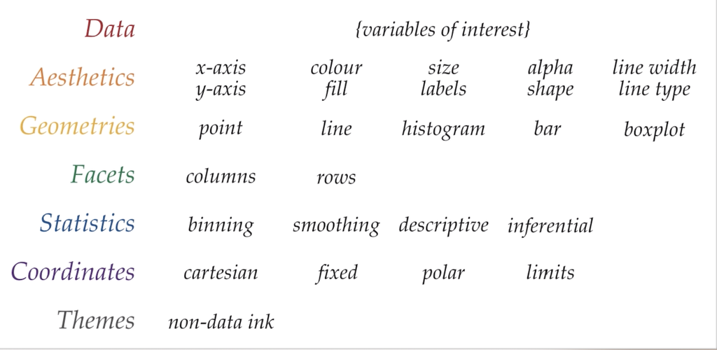

## Using `ggplot()`

## Data and aesthetics

The function `ggplot()` has two main arguments:

```r
ggplot(data = <data>, mapping = aes(x = <var>, y = <var>, ...))
```

- `<data>` name of the data set
- `mapping` maps variables to `aes`thetics
- `...` mapping to color, shape, size, etc.

## Example

- `ggplot(mpg)` creates an empty plot array for data set `mpg`
- `aes(x = cty, y = displ)` maps variable values to axes

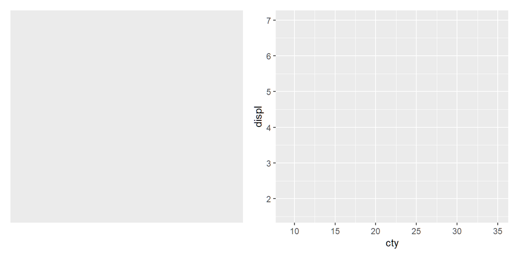

```r
ggplot(mpg) +
  ggplot(mpg, aes(x = cty, y = displ))
```

- The `+` symbol is from the `patchwork` package
  - it displays plot side-by-side (`+` does the same)
  - `/` displays plots on top of each other

## Geoms

The geoms tell `ggplot()` what shapes to display, e.g.,

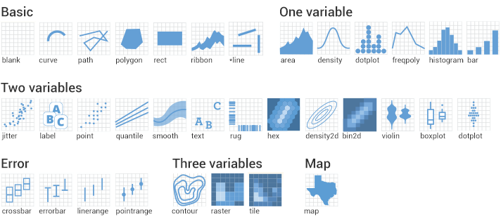

```r
ggplot(<data>, aes(x = <var>, y = <var>)) +
  geom_xxx()
```

## Scatter plot

With `cty` and `disp` with

- add points with `geom_point()`
- add a regression line with `geom_smooth()`

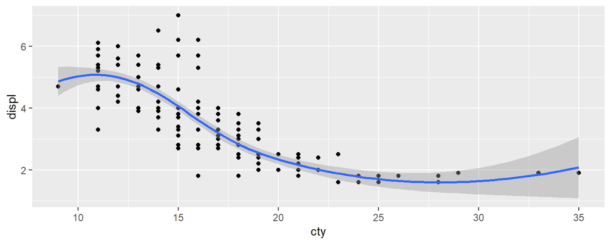

```r
ggplot(mpg, aes(cty, displ)) +
  geom_point() +
  geom_smooth()
```

## Adding the aesthetic `color`

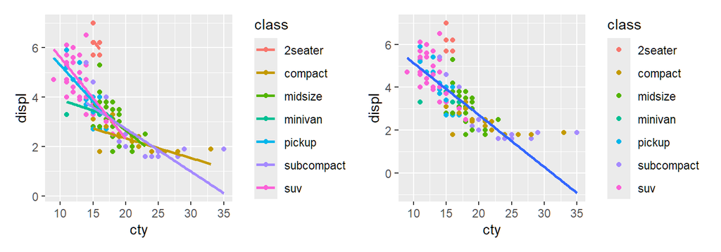

```r
ggplot(mpg, aes(cty, displ, col = class)) +
  geom_point() +
  geom_smooth(method = "lm", se = F) +

ggplot(mpg, aes(cty, displ)) +
  geom_point(aes(col = class)) +
  geom_smooth(method = "lm", se = F)
```

## Plot for categorical data

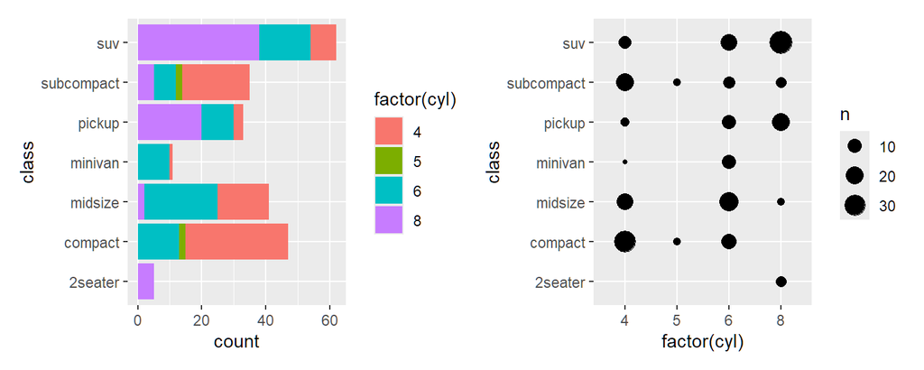

```r
ggplot(mpg) +
    geom_bar(aes(y = class, fill = factor(cyl))) +
  ggplot(mpg) +
    geom_count(aes(factor(cyl), class))
```

## Collext axes labels

The `class` labels are displayed once

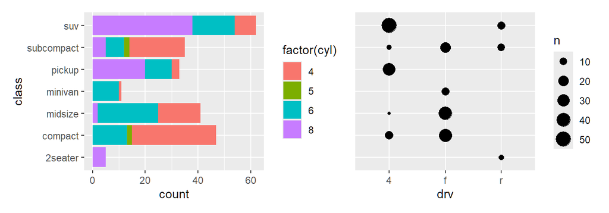

```r
ggplot(mpg) +
  geom_bar(aes(class, fill = factor(cyl))) +
  coord_flip() +
ggplot(mpg) +
  geom_count(aes(drv, class)) +
plot_layout(axes = 'collect')
```

## Coordinates

Change the scale of the axes

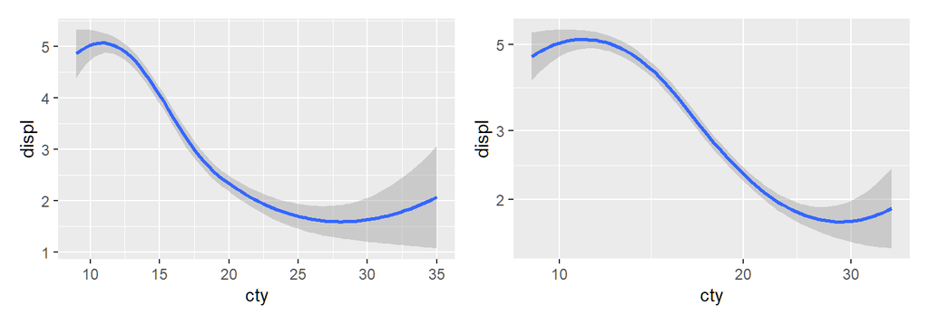

```r
ggplot(mpg, aes(cty, displ)) +
  geom_smooth() +
ggplot(mpg, aes(cty, displ)) +
  geom_smooth() +
  scale_x_log10() +
  scale_y_log10()
```

## Facets

Make separate plots for the levels of a categorical variable (`factor`)

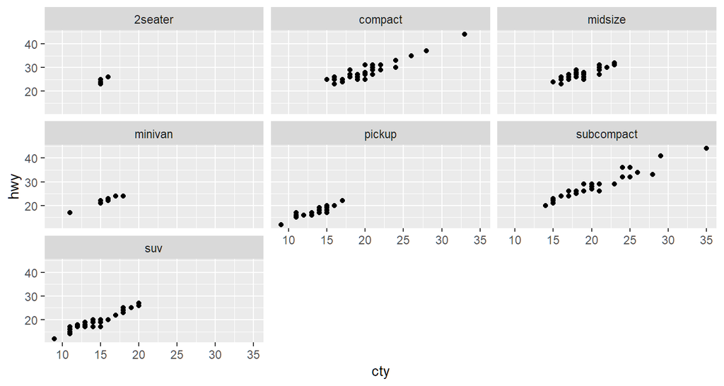

```r
ggplot(mpg, aes(x = cty, y = hwy)) +
  geom_point() +
  facet_wrap(vars(class))
```

## Themes

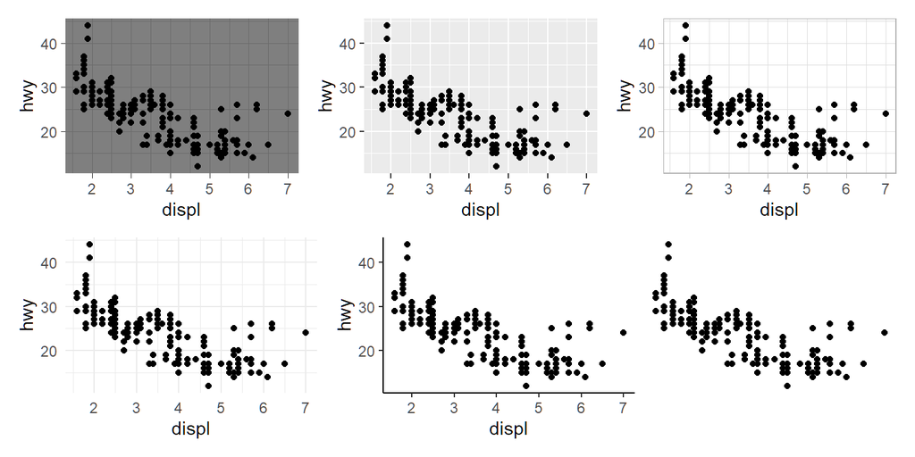

```r
p <- ggplot(mpg, aes(displ, hwy)) + geom_point()

(p + theme_dark()    | p + theme_gray()    | p + theme_light())  /
(p + theme_minimal() | p + theme_classic() | p + theme_void())
```

## Statistics

## Custom regression line

Change the type of regression line.

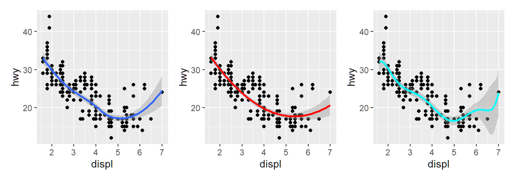

```r
p + geom_smooth() +
p + geom_smooth(method = "lm", formula = y ~ poly(x, 2), col = "red") +
p + geom_smooth(method = "lm", formula = y ~ poly(x, 8), col = 'cyan')
```

## Histogram with normal curve

Change histogram from counts to density and add normal curve

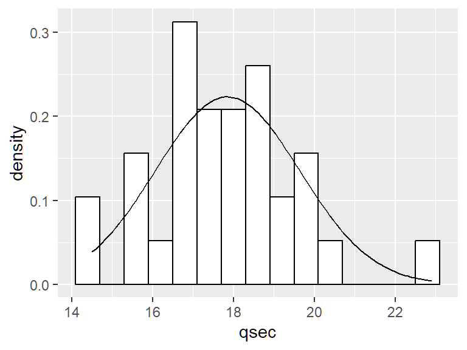

```r
ggplot(mtcars, aes(qsec))+
  geom_histogram(aes(y = after_stat(density)), bins = 15, fill = "white", col= "black") +
  stat_function(fun = dnorm, args = list(mean(mtcars$qsec), sd(mtcars$qsec)))
```

## Barplots

Three different bar plots

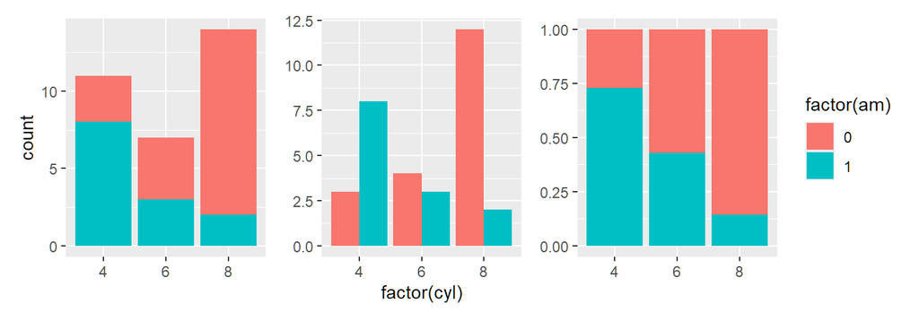

```r
ggplot(mtcars, aes(x = factor(cyl), fill = factor(am))) +
    geom_bar() +
ggplot(mtcars, aes(x = factor(cyl), fill = factor(am))) +
  geom_bar(position = "dodge") +
ggplot(mtcars, aes(x = factor(cyl), fill = factor(am))) +
  geom_bar(position = "fill") +
  plot_layout(guides = 'collect', axes = 'collect')
```

## Coordinates

## Coordinate systems

Cartesian is most common, polar is for circular plots.

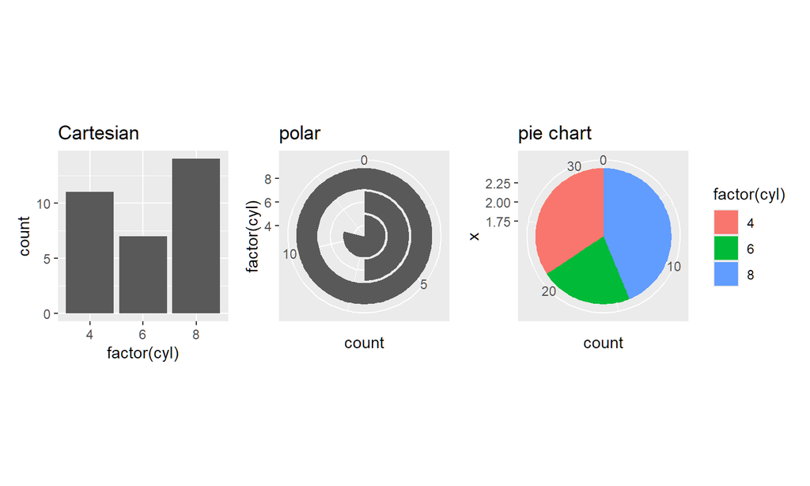

```r
ggplot(mtcars, aes(factor(cyl))) +
  geom_bar() +
  ggtitle("Cartesian") +

  ggplot(mtcars, aes(factor(cyl))) +
  geom_bar() +
  coord_polar(theta="y") +
  ggtitle("polar") +

  mtcars %>% mutate(x = 2) %>%
  ggplot() +
  geom_bar(aes(x = x, fill = factor(cyl))) +
  coord_polar(theta = "y") +
  ggtitle("pie chart")
```

## Coordinate systems

Polar system (not recommended)

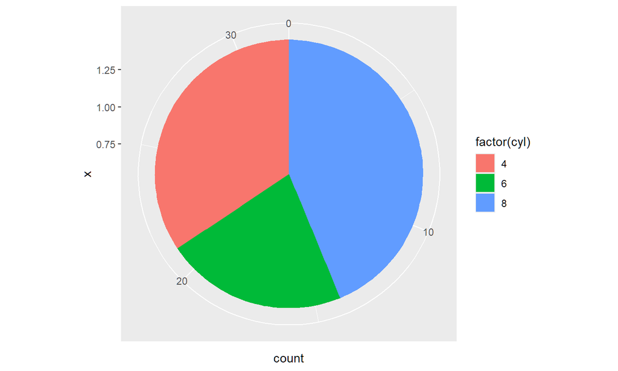

```r
ggplot(mtcars) +
  geom_bar(aes(x = 1, fill = factor(cyl))) +
  coord_polar(theta = "y")
```

## Flip the axes

Change orientation of the plot with `coord_flip()`

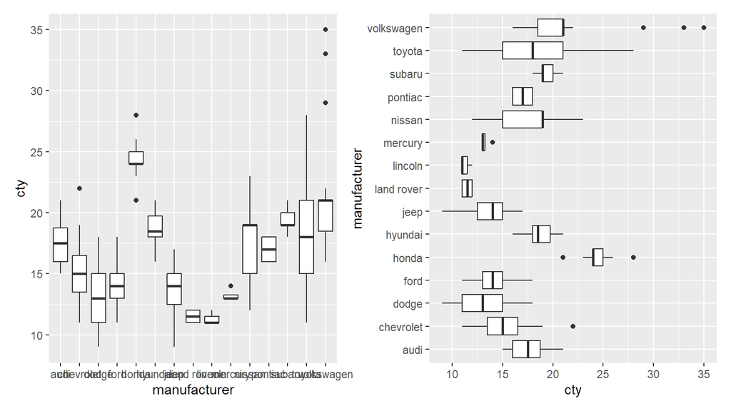

```r
q <- ggplot(mpg, aes(manufacturer, cty)) +
  geom_boxplot()

q +
  q + coord_flip()
```

## Themes

## Non-data ink

Appearance of the plot, e.g., background color, fonts, etc.

There are pre-specified themes, e.g.:

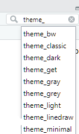

You can also design a theme yourself.

## Exercise

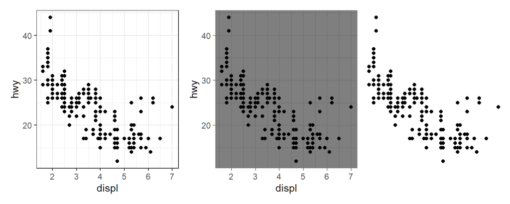

```r
p + theme_bw() +
  p + theme_dark() +
  p + theme_void()
```

## Pipes and ggplot

## Plotting manipulated data

For complex data it can be efficient to combine a pipe with `ggplot()`, e.g.:

```r
data %>%
  filter(logical expressions) %>%
  mutate(newvar = expression) %>%
  ggplot(aes(x = newvar)) +
  geom_point()
```

## Example

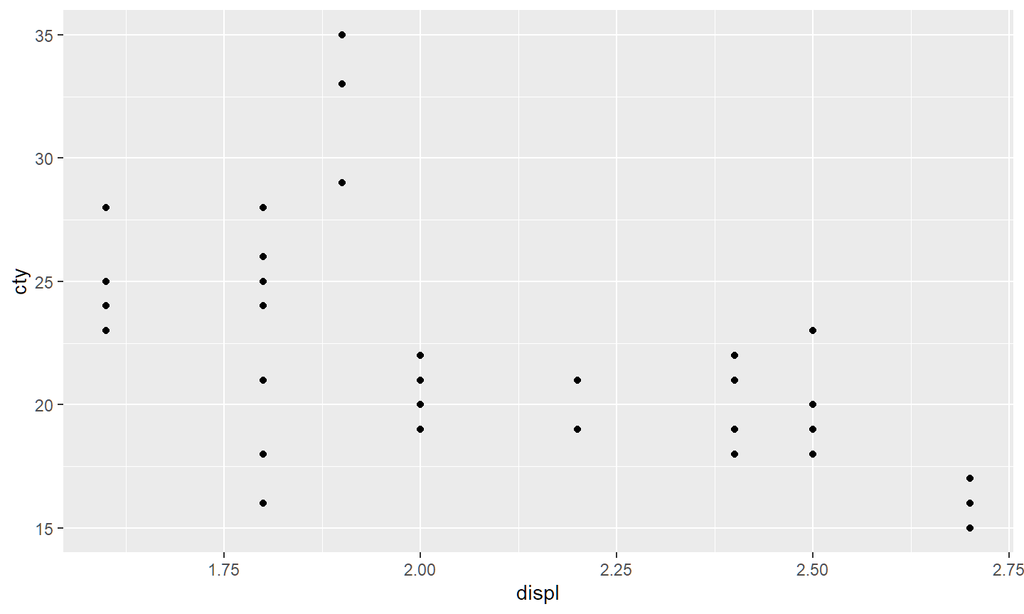

```r
mpg %>%
  filter(cyl == 4) %>%
  ggplot(aes(displ, cty)) +
  geom_point()
```

## R Markdown

## Resizing plots

With multiple plots in a single array

- resize the plot array so that plot are approximately square
- with the `fig` chunk options
  - `fig.width` to adjust the width of the array (default = 7)
  - `fig.height` to adjust the height of the array (default = 5)
  - `fig.asp` to change height:width ratio (default 5/7)

Example to make the plot array smaller and higher

`` ```{r fig.width = 6, fig.height = 8} ``